# Obtaining Posstratification-Frame fir 2019 UK General Election

## Summary of the Project

- downloaded census data and binned age/education variables to form 32 demographic Groups
- dowloaded BES random proability survey data and used it to estimate a MRP model for vote choice
- downloaded and merged 2015, 2017 and 2019 BES ranom prob. data to estimate aturnout model using XGBoost
- used the MRP model to predict vote choice and the turnout model to predict turnout probabilities for each demographic group
- merged the census data with the BES data and estimated the party probabilites number of votes for each party in each constituency
- scaled the estimated votes to match the actual results and saved the final post-stratification frame to a csv file

## Census Data

- Load and explore Census data.
- Clean demographic variables for BES data matching later on

```r
# AGE: renaming and filtering
# age_code: census$Age..B...14.categories..Code, age_label: census$Age..B...14.categories..Label
census <- census %>%
  rename(age_code = Age..B...14.categories..Code,
         age_label = Age..B...14.categories.) %>%
  filter(age_code >= 3 & age_code <= 14) %>%
  mutate(age_group = case_when(
    age_code %in% c(3, 4, 5, 6) ~ "Aged 20 to 39 years",
    age_code %in% c(7, 8, 9, 10) ~ "Aged 40 to 59 years",
    age_code %in% c(11) ~ "Aged 60 to 74 years",
    age_code %in% c(12, 13, 14) ~ "Aged 75 years and over"
  ))

# EDUCTION: renaming and recoding
census <- census %>%
  rename(education_code = Highest.level.of.qualification..8.categories..Code,
         education_label = Highest.level.of.qualification..8.categories.) %>%
  mutate(education_recode = case_when(
    education_code %in% c(0, 1) ~ 0,  # no qualifications/low qualifications
    education_code %in% c(2, 3) ~ 1,  # intermediate qualifications
    education_code %in% c(4, 5) ~ 2,  # advanced level/higher education
    TRUE ~ 3  # other/not categorized
  )) %>%
  mutate(education_recode = factor(education_recode,
                                   labels = c("No/Low Qualifications",
                                              "Intermediate Qualifications",
                                              "Advanced/Higher Education",
                                              "Other/Not Categorized")))

# SEX: renaming
census <- census %>%
  rename(sex_code = Sex..2.categories..Code,  # female = 1, male = 0
         sex_label = Sex..2.categories.) %>%
  group_by(age_group, education_recode, sex_label, Westminster.Parliamentary.constituencies.Code) %>%
  summarise(total_observations = sum(Observation))
```

[output not shown]

# Census Data Descriptives

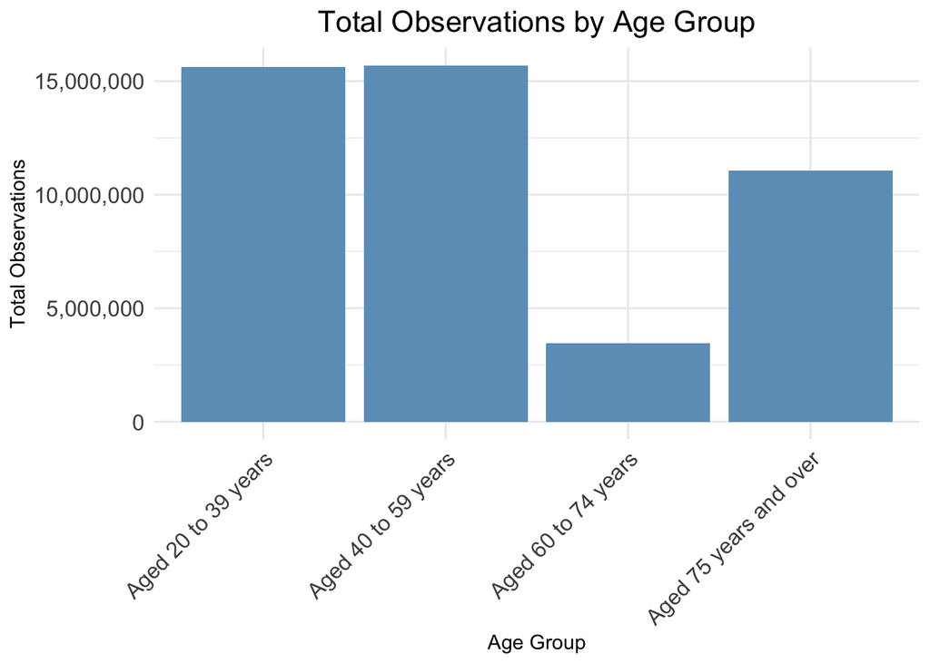

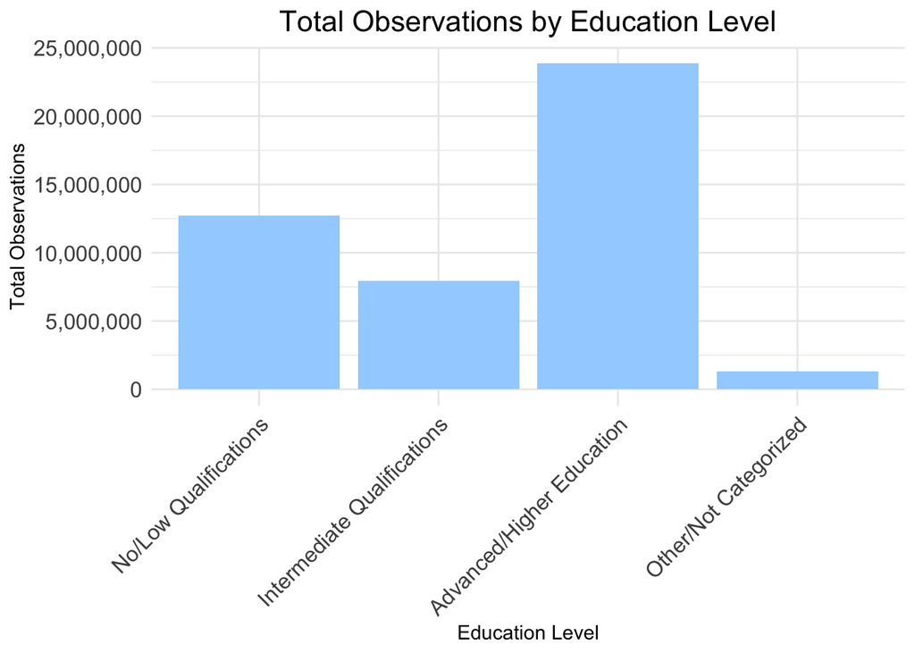

# # BES data - Using unweighted raw responses to BES questions - Cleaning and recoding variables to match census data

[output not shown]

## `summarise()` has grouped output by ‘age_group’. You can override using the

## `.groups` argument.

[output not shown]

[output cut: 21 more lines]

```
training_data_xgb <- training_data
testing_data_xgb <- testing_data

# make sure the colums are all factor variables:
training_data_xgb <- training_data_xgb %>%
  mutate_if(is.character, as.factor)

# drop NA rows
training_data_xgb <- na.omit(training_data_xgb)
testing_data_xgb <- na.omit(testing_data_xgb)

training_data_xgb$turned_out <- as.numeric(as.character(training_data_xgb$turned_out))
testing_data_xgb$turned_out <- as.numeric(as.character(testing_data_xgb$turned_out))

training_data_xgb$turned_out[1:10]
```

```
##  [1] 1 1 1 1 1 1 0 1 1 1
```

```r
#  matrices for XGBoost
dtrain <- xgb.DMatrix(data = data.matrix(training_data_xgb[, -which(names(training_data_xgb) == "turned_out")]),
                      label = training_data_xgb$turned_out)
dtest <- xgb.DMatrix(data = data.matrix(testing_data_xgb[, -which(names(testing_data_xgb) == "turned_out")]),
                     label = testing_data_xgb$turned_out)

# turnout model : logistic regressoin
turnout_model <- glmer(formula = turned_out ~ age_group + education_recode +
                       sex_label + (1 | Cluster_Group), # add constituency group
                       family = binomial(link = "logit"),
                       data = training_data,
                       # dont print out iuteratinos
                       control = glmerControl( optCtrl = list(maxfun = 2e5)))


# XGBoost Model
params <- list(booster = "gbtree", objective = "binary:logistic", eta = 0.3, max_depth = 6)
xgb_model <- xgb.train(params = params, data = dtrain, nrounds = 100)

# predict and calculate accuracy
logistic_preds <- predict(turnout_model, newdata = testing_data, type = "response")
binary_logistic_preds <- as.numeric(logistic_preds > 0.5)

# Ensure testing_data$turned_out is a numeric vector
testing_data$turned_out <- as.numeric(as.character(testing_data$turned_out))

# Calculate accuracy
logistic_accuracy <- mean(binary_logistic_preds == testing_data$turned_out)

# XGBoost predictions
xgb_preds <- predict(xgb_model, dtest)
xgb_preds <- as.vector(xgb_preds)
xgb_accuracy <- mean((xgb_preds > 0.5) == testing_data_xgb$turned_out)

# compare accuracies
accuracy_comparison <- data.frame(Model = c("Logistic Regression", "XGBoost"),
                                  Accuracy = c(logistic_accuracy, xgb_accuracy))

print(accuracy_comparison)
```

```
##                 Model  Accuracy
## 1 Logistic Regression 0.7945205
## 2             XGBoost 0.8794521
```

# Fitting Vote and Turnout Models

```r
# multinomial and brms models for party voted for
# party_model_old <- multinom(party_voted_for ~  age_group + education_recode +
                          #sex_label  + a03 + j01 +
                          #as.factor(y26) + age_group:sex_label:education_recode,
                          #data = BES_voted)

# look at the default priors
# get_prior(formula = as.factor(party_voted_for) ~ age_group + education_recode + sex_label +
          #a03 + j01 + as.factor(y26) +
          #(1 | (Cluster_Group)),
          #family = categorical(link = "logit"),
          #data = BES_voted)

party_model <- brm(
    formula = as.factor(party_voted_for) ~ age_group + education_recode + sex_label +
              a03 + j01 + (1 | Cluster_Group), #  + as.factor(y26)
    family = categorical(link = "logit"),
    data = BES_voted,
    cores = 6,
    chains = 4,
    iter = 2000)
# summary(party_model)
pp_check(party_model)
```

```
## Using 10 posterior draws for ppc type 'dens_overlay' by default.
```

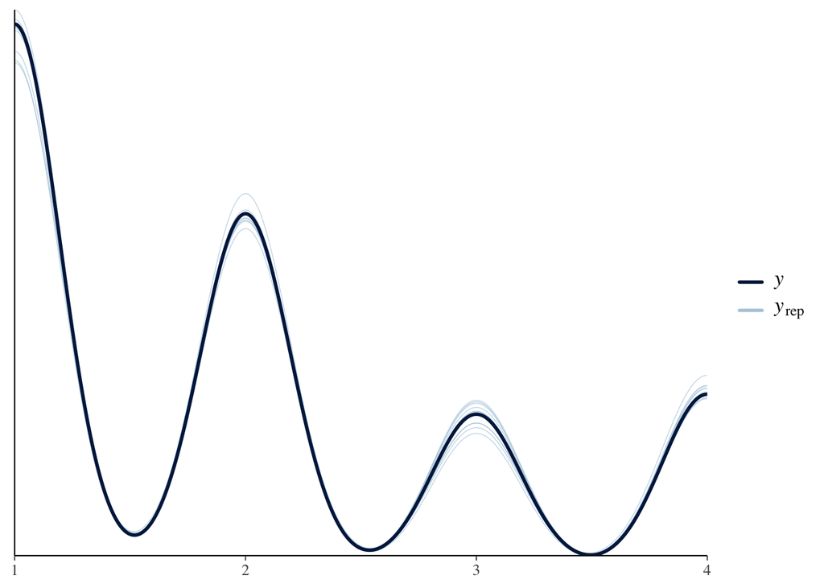

# # # Predicting on BES data and aggregating at demographic group level

```r
######MULTINOMIAL CASE:
# predicted_probs <- party_predictions_old
# party_model <- party_model_old
##################

# XGBoost predictions for turnout probabilities
# Remove the response variable 'turned_out'
BES_for_xgb <- BES[, -which(names(BES) == "turned_out")]
dmatrix_for_prediction <- xgb.DMatrix(data = data.matrix(BES_for_xgb))
xgb_probs <- predict(xgb_model, dmatrix_for_prediction)
BES$predicted_turnout <- xgb_probs

# vote predictions
predicted_probs <- predict(party_model, BES)

# preparing predicted probabilities
predicted_probs_df <- as.data.frame(predicted_probs)
colnames(predicted_probs_df) <- c("Con", "Lab", "Lib", "Other")
head(predicted_probs_df)
```

```
##       Con     Lab     Lib   Other
## 1 0.43450 0.20550 0.19550 0.16450
## 2 0.40900 0.27150 0.17950 0.14000
## 3 0.44300 0.21600 0.14650 0.19450
## 4 0.62825 0.11850 0.13450 0.11875
## 5 0.22700 0.28875 0.21675 0.26750
## 6 0.64525 0.16950 0.09850 0.08675
```

```r
# cleaning BES data and combining with predicted probabilities
BES_cleaned <- BES %>%
  select(age_group, education_recode, sex_label,
        turned_out, predicted_turnout, party_voted_for,
        Constit_Code, a03, j01, y26, constituency, Cluster_Group) %>%
  cbind(predicted_probs_df)

# aggregating BES Predictions by demographic variables
BES_aggregated <- BES_cleaned %>%
  group_by(age_group, education_recode, sex_label) %>%
  summarise(
    avg_predicted_turnout_prob = mean(predicted_turnout, na.rm = TRUE),
    avg_con = mean(Con, na.rm = TRUE),
    avg_lab = mean(Lab, na.rm = TRUE),
    avg_lib = mean(Lib, na.rm = TRUE),
    avg_other = mean(Other, na.rm = TRUE)
  )
```

# Visualizing Predictions

```
## Top 3 Highest Turnout Demographic Groups:
```

```
## # A tibble: 3 × 3
## # Groups:   age_group [2]
##   age_group              education_recode            avg_turnout_rate
##   <fct>                  <fct>                                  <dbl>
## 1 Aged 75 years and over Advanced/Higher Education              0.940
## 2 Aged 60 to 74 years    Other/Not Categorized                  0.895
## 3 Aged 75 years and over Intermediate Qualifications            0.886
```

```
##
## Lowest 3 Turnout Demographic Groups:
```

```
## # A tibble: 3 × 3
## # Groups:   age_group [1]
##   age_group           education_recode            avg_turnout_rate
##   <fct>               <fct>                                  <dbl>
## 1 Aged 20 to 39 years No/Low Qualifications                  0.726
## 2 Aged 20 to 39 years Intermediate Qualifications            0.621
## 3 Aged 20 to 39 years Other/Not Categorized                  0.551
```

Summary Table of Predictions

| age_group | education_recode | avg_predicted_turnout_prob | avg_con | avg_lab | avg_lib | avg_other |
| --- | --- | --- | --- | --- | --- | --- |
| Aged 20 to 39 years | No/Low Qualifications | 0.7261582 | 0.2346035 | 0.4934659 | 0.1219634 | 0.1499672 |
| Aged 20 to 39 years | Intermediate Qualifications | 0.6205688 | 0.3268291 | 0.4053182 | 0.0851508 | 0.1827019 |
| Aged 20 to 39 years | Advanced/Higher Education | 0.7447641 | 0.3155442 | 0.4557948 | 0.0760304 | 0.1526306 |
| Aged 20 to 39 years | Other/Not Categorized | 0.5508332 | 0.3001493 | 0.3677101 | 0.1581311 | 0.1740095 |
| Aged 40 to 59 years | No/Low Qualifications | 0.8049572 | 0.3931533 | 0.3042557 | 0.1404520 | 0.1621390 |
| Aged 40 to 59 years | Intermediate Qualifications | 0.8032886 | 0.5068438 | 0.2251355 | 0.0963584 | 0.1716623 |
| Aged 40 to 59 years | Advanced/Higher Education | 0.8298387 | 0.4908044 | 0.2569690 | 0.0907118 | 0.1615148 |
| Aged 40 to 59 years | Other/Not Categorized | 0.7625712 | 0.4500905 | 0.1934615 | 0.1832464 | 0.1732016 |
| Aged 60 to 74 years | No/Low Qualifications | 0.8562081 | 0.5015413 | 0.2216759 | 0.1308548 | 0.1459280 |
| Aged 60 to 74 years | Intermediate Qualifications | 0.8475193 | 0.5955745 | 0.1632689 | 0.0914460 | 0.1497106 |
| Aged 60 to 74 years | Advanced/Higher Education | 0.8477631 | 0.5993625 | 0.1866792 | 0.0830613 | 0.1308970 |
| Aged 60 to 74 years | Other/Not Categorized | 0.8947733 | 0.5443562 | 0.1531359 | 0.1299390 | 0.1725689 |
| Aged 75 years and over | No/Low Qualifications | 0.8675636 | 0.5640068 | 0.2008266 | 0.1308674 | 0.1042992 |
| Aged 75 years and over | Intermediate Qualifications | 0.8855226 | 0.6520688 | 0.1545492 | 0.1025744 | 0.0908075 |
| Aged 75 years and over | Advanced/Higher Education | 0.9401593 | 0.6449510 | 0.1846427 | 0.0667865 | 0.1036198 |
| Aged 75 years and over | Other/Not Categorized | 0.8840856 | 0.6098373 | 0.1292596 | 0.1571891 | 0.1037139 |

# Merging Census and BES data

```r
# aligning education_recode levels in BES_aggregated to match census
levels(BES_aggregated$education_recode) <- c("No/Low Qualifications",
                                             "Intermediate Qualifications",
                                             "Advanced/Higher Education",
                                             "Other/Not Categorized")

#  sex_label asfactor with consistent levels (if necessary)
if(!is.null(levels(census$sex_label)) && !is.null(levels(BES_aggregated$sex_label))) {
  levels(BES_aggregated$sex_label) <- levels(census$sex_label)
}

#
poststrat_data <- census %>%
  left_join(BES_aggregated, by = c("age_group", "education_recode", "sex_label"))

# estimating votes on post-stratification data
poststrat_data <- poststrat_data %>%
  mutate(
    est_votes_con = total_observations * avg_predicted_turnout_prob * avg_con,
    est_votes_lab = total_observations * avg_predicted_turnout_prob * avg_lab,
    est_votes_lib = total_observations * avg_predicted_turnout_prob * avg_lib,
    est_votes_other = total_observations * avg_predicted_turnout_prob * avg_other
  )
```

# Poststratification

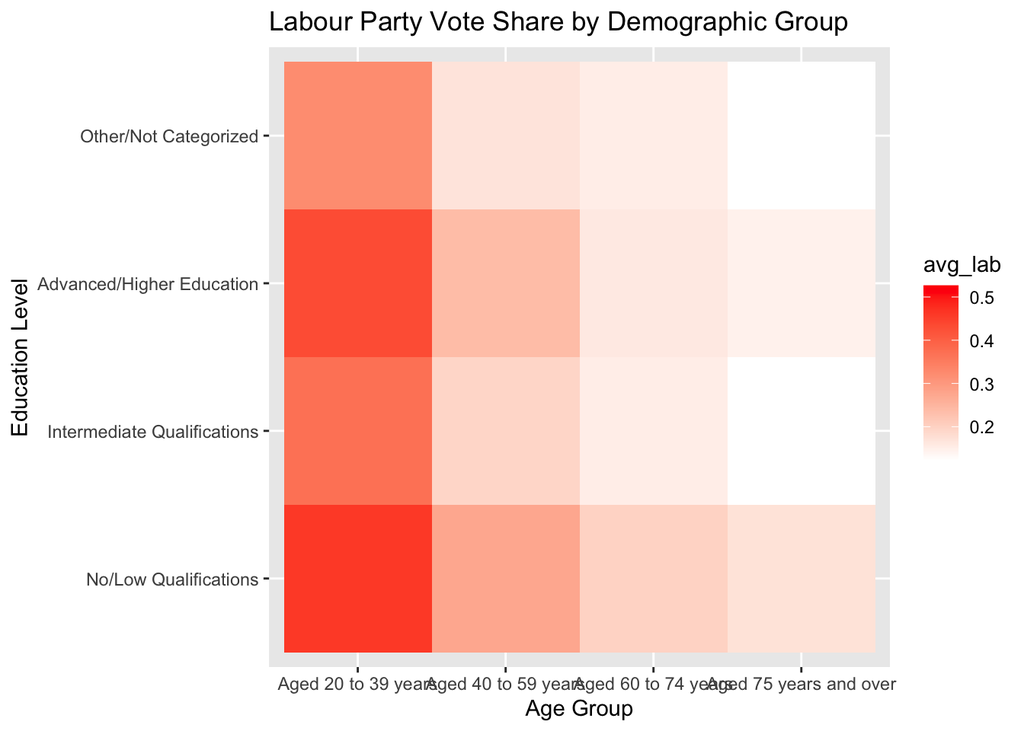

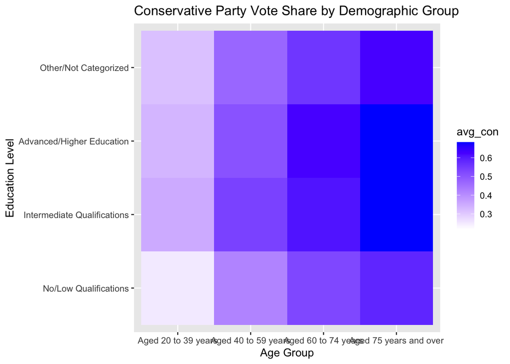

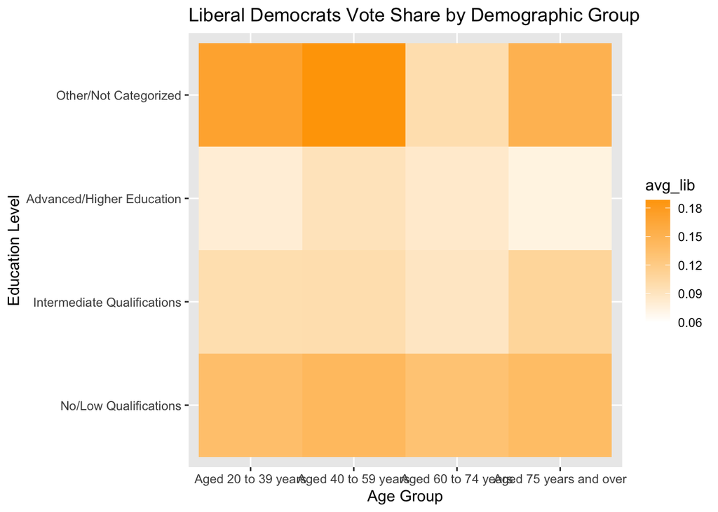

```r
# filter actual results to only include constituencies in the poststratification frame
actual_results <- actual_results %>%
  filter(Country == 1 | Country == 3) %>%
  select(ONSConstID, Winner19, ConVote19, LabVote19, LDVote19, TotalVote19) %>%
  mutate(OtherVote19 = TotalVote19 - (ConVote19 + LabVote19 + LDVote19))

# aggregate estimated votes by constituency
constituency_estimates <- poststrat_data %>%
  group_by(Westminster.Parliamentary.constituencies.Code) %>%
  summarise(
    est_votes_con_total = sum(est_votes_con),
    est_votes_lab_total = sum(est_votes_lab),
    est_votes_lib_total = sum(est_votes_lib),
    est_votes_other_total = sum(est_votes_other)
  )

# join with actual results
comparison <- constituency_estimates %>%
  left_join(actual_results, by = c("Westminster.Parliamentary.constituencies.Code" = "ONSConstID"))

# calculate scaling factors and apply them
comparison <- comparison %>%
  mutate(
    scale_factor_con = ConVote19 / est_votes_con_total,
    scale_factor_lab = LabVote19 / est_votes_lab_total,
    scale_factor_lib = LDVote19 / est_votes_lib_total,
    scale_factor_other = OtherVote19 / est_votes_other_total
  ) %>%
  mutate(
    scaled_est_votes_con = est_votes_con_total * scale_factor_con,
    scaled_est_votes_lab = est_votes_lab_total * scale_factor_lab,
    scaled_est_votes_lib = est_votes_lib_total * scale_factor_lib,
    scaled_est_votes_other = est_votes_other_total * scale_factor_other
  )

# apply scaling factors to poststrat data
final_poststrat_data <- poststrat_data %>%
  left_join(comparison %>%
            select(Westminster.Parliamentary.constituencies.Code,
                   scale_factor_con,
                   scale_factor_lab,
                   scale_factor_lib,
                   scale_factor_other),
            by = "Westminster.Parliamentary.constituencies.Code") %>%
  mutate(
    scaled_est_votes_con = est_votes_con * scale_factor_con,
    scaled_est_votes_lab = est_votes_lab * scale_factor_lab,
    scaled_est_votes_lib = est_votes_lib * scale_factor_lib,
    scaled_est_votes_other = est_votes_other * scale_factor_other
  )
# sort by constituency
final_poststrat_data <- final_poststrat_data[order(final_poststrat_data$Westminster.Parliamentary.constituencies.Code), ]
View(final_poststrat_data)

# round the vote counts to the nearest integer (scaled and non scaled!)
final_poststrat_data <- final_poststrat_data %>%
  mutate(
    est_votes_con = round(est_votes_con),
    est_votes_lab = round(est_votes_lab),
    est_votes_lib = round(est_votes_lib),
    est_votes_other = round(est_votes_other),
    scaled_est_votes_con = round(scaled_est_votes_con),
    scaled_est_votes_lab = round(scaled_est_votes_lab),
    scaled_est_votes_lib = round(scaled_est_votes_lib),
    scaled_est_votes_other = round(scaled_est_votes_other)
  )

# drop the est columns
final_poststrat_data <- final_poststrat_data %>%
  select(-starts_with("est"))

# save final poststratification frame to a csv file
write.csv(final_poststrat_data, file = "final_poststrat_data.csv")

# also save a 100 row long snippet of the final poststratification frame
write.csv(final_poststrat_data[1:100, ], file = "final_poststrat_data_snippet.csv")
```